# mlr3 Workshop

## mlr3 pipelines

### Simple GraphLearners

Obviously removing certain columns will likely result in worse prediction quality. We will combine the learners that can not handle missing data with a simple imputation strategy to be able to train them on the task with missing values.

```r
# construct the learners
lrns_nomissing = lapply(c("classif.log_reg", "classif.kknn", "classif.ranger"), lrn)
as.data.table(mlr_pipeops) # show available pipeops
```

```
##                 key      packages input.num output.num input.type.train
##  1:          boxcox bestNormalize         1          1             Task
##  2:          branch                       1         NA                *
##  3:           chunk                       1         NA             Task
##  4:  classbalancing                       1          1             Task
##  5:      classifavg         stats        NA          1             NULL
##  6:        colapply                       1          1             Task
##  7: collapsefactors                       1          1             Task
##  8:            copy                       1         NA                *
##  9:          encode         stats         1          1             Task
## 10:      encodelmer   lme4,nloptr         1          1             Task
## 11:    featureunion                      NA          1             Task
## 12:          filter                       1          1             Task
## 13:      fixfactors                       1          1             Task
## 14:         histbin      graphics         1          1             Task
```

[output cut: 69 more lines]

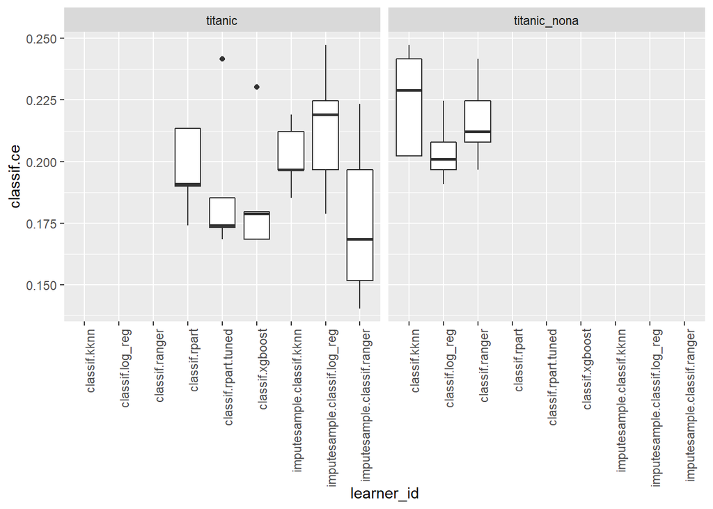

```r
# we decide for sampling imputation because it works for numerics and factors.
# in front of each learner we put the imputesample PipeOp
lrns_sampleimp = lapply(lrns_nomissing, function(lrn) {
  pipe = po("imputesample") %>>% po("learner", learner = lrn)
  GraphLearner$new(pipe)
})

# benchmark the learners with sample imputation
design_impute = benchmark_grid(
  tasks = titanic_tsk,
  learners = lrns_sampleimp,
  resamplings = rds)
res3 = benchmark(design = design_impute)

# add the results to the previous benchmark result
res$combine(res3)

# plot the updated result
library(ggplot2)
mlr3viz::autoplot(res) + theme(axis.text.x = element_text(angle = 90, hjust = 1))
```

The random forest (`classif.ranger`) with imputation worked quite well. We want to find out if we can improve the performance if we optmize the choice of the imputation strategy and the hyperparameters of the random forest. Therefore we will create a pipe that first imputes missing numerical values, then missing categorical values and at the end trains a random forest on the imputed data.

```r
impute_pos = as.data.table(mlr_pipeops)[grepl("impute", key)] # show available pipeops
impute_pos
```

```
##             key packages input.num output.num input.type.train
## 1:   imputehist graphics         1          1             Task
## 2:   imputemean                  1          1             Task
## 3: imputemedian    stats         1          1             Task
## 4: imputenewlvl                  1          1             Task
## 5: imputesample                  1          1             Task
##    input.type.predict output.type.train output.type.predict
## 1:               Task              Task                Task
## 2:               Task              Task                Task
## 3:               Task              Task                Task
## 4:               Task              Task                Task
## 5:               Task              Task                Task
```

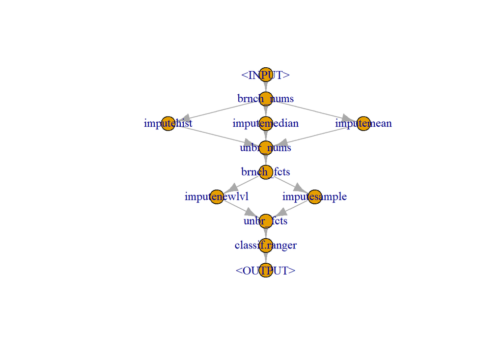

```r
impute_nums = c("imputehist", "imputemedian", "imputemean") #imputing strategies for numerical values
impute_fcts = c("imputenewlvl", "imputesample") #... for categorical (factor) values

# Branching pipeops for numerical and factor imputation
po_branch_nums = po("branch", options = impute_nums, id = "brnch_nums")
po_branch_fcts = po("branch", options = impute_fcts, id = "brnch_fcts")

# Pipeops for numerical imputation
pos_impute_nums = lapply(impute_nums, po)
pos_impute_nums = gunion(pos_impute_nums)

# Pipeops for factor imputation
pos_impute_fcts = lapply(impute_fcts, po)
pos_impute_fcts = gunion(pos_impute_fcts)

# Build complete pipe
pipe = po_branch_nums %>>% pos_impute_nums %>>% po("unbranch", id = "unbr_nums") %>>%
  po_branch_fcts %>>% pos_impute_fcts %>>% po("unbranch", id = "unbr_fcts") %>>%
  po("learner", learner = lrn("classif.ranger", num.trees = 200))
# Plot the pipes layout.
plot(pipe)
```

```r
grph_lrn = GraphLearner$new(pipe)

# Define Tuning

# ParamSet
grph_lrn$param_set
```

```
## ParamSet:
##                                              id    class lower upper
##  1:                        brnch_nums.selection ParamFct    NA    NA
##  2:                   imputehist.affect_columns ParamUty    NA    NA
##  3:                 imputemedian.affect_columns ParamUty    NA    NA
##  4:                   imputemean.affect_columns ParamUty    NA    NA
##  5:                        brnch_fcts.selection ParamFct    NA    NA
##  6:                 imputenewlvl.affect_columns ParamUty    NA    NA
##  7:                 imputesample.affect_columns ParamUty    NA    NA
##  8:                    classif.ranger.num.trees ParamInt     1   Inf
##  9:                         classif.ranger.mtry ParamInt     1   Inf
## 10:                   classif.ranger.importance ParamFct    NA    NA
## 11:                 classif.ranger.write.forest ParamLgl    NA    NA
## 12:                classif.ranger.min.node.size ParamInt     1   Inf
## 13:                      classif.ranger.replace ParamLgl    NA    NA
```

[output cut: 42 more lines]

```r
par_set = ParamSet$new(params = list(
  grph_lrn$param_set$params$brnch_nums.selection,
  grph_lrn$param_set$params$brnch_fcts.selection,
  ParamInt$new(id = "classif.ranger.mtry", lower = 1, upper = titanic_tsk$ncol-1),
  ParamInt$new(id = "classif.ranger.min.node.size", lower = 1, upper = 20)
))

# Tuning Budget
term_evals = term("evals", n_evals = 20)

# Tuning Instance
instance = TuningInstance$new(
  task = titanic_tsk,
  learner = grph_lrn,
  resampling = rsmp("cv", folds = 3),
  measures = msr("classif.ce"),
  param_set = par_set,
  terminator = term_evals
)

# Construct and start tuner
tuner = tnr("random_search")
tuner$tune(instance)
# Analyze the tuning result
instance$result
```

```
## $tune_x
## $tune_x$brnch_nums.selection
## [1] "imputemedian"
##
## $tune_x$brnch_fcts.selection
## [1] "imputesample"
##
## $tune_x$classif.ranger.mtry
## [1] 6
##
## $tune_x$classif.ranger.min.node.size
## [1] 6
##
##
## $params
## $params$brnch_nums.selection
## [1] "imputemedian"
##
## $params$brnch_fcts.selection
## [1] "imputesample"
##
## $params$classif.ranger.num.trees
## [1] 200
##
## $params$classif.ranger.mtry
## [1] 6
##
## $params$classif.ranger.min.node.size
## [1] 6
##
##
## $perf
## classif.ce
##  0.1649832
```

```r
instance$archive(unnest = "tune_x")
```

```
##     nr batch_nr  resample_result task_id
##  1:  1        1 <ResampleResult> titanic
##  2:  2        2 <ResampleResult> titanic
##  3:  3        3 <ResampleResult> titanic
##  4:  4        4 <ResampleResult> titanic
##  5:  5        5 <ResampleResult> titanic
##  6:  6        6 <ResampleResult> titanic
##  7:  7        7 <ResampleResult> titanic
##  8:  8        8 <ResampleResult> titanic
##  9:  9        9 <ResampleResult> titanic
## 10: 10       10 <ResampleResult> titanic
## 11: 11       11 <ResampleResult> titanic
## 12: 12       12 <ResampleResult> titanic
## 13: 13       13 <ResampleResult> titanic
## 14: 14       14 <ResampleResult> titanic
```

[output cut: 90 more lines]

With a nested cross-validation setting we can assess the unbiased performance of the tuned random forest.

```r
# similar as above we construct the self tuning learner
grph_lrn_at = AutoTuner$new(
  learner = grph_lrn,
  resampling = rsmp("cv", folds = 3),
  measures = msr("classif.ce"),
  tune_ps = par_set,
  terminator = term_evals,
  tuner = tnr("random_search")
)
grph_lrn_at$id
```

```
## [1] "brnch_nums.imputehist.imputemedian.imputemean.unbr_nums.brnch_fcts.imputenewlvl.imputesample.unbr_fcts.classif.ranger.tuned"
```

```r
# give this Learner a shorter ID (usefull for the plot)
grph_lrn_at$id = "rf_tuned_impute"


rsmpl_res_graph_at = resample(titanic_tsk, grph_lrn_at, rds) #rds is taken from above (rds = rsmp("cv"))
rsmpl_res_graph_at$aggregate()
```

```
## classif.ce
##  0.1717155
```

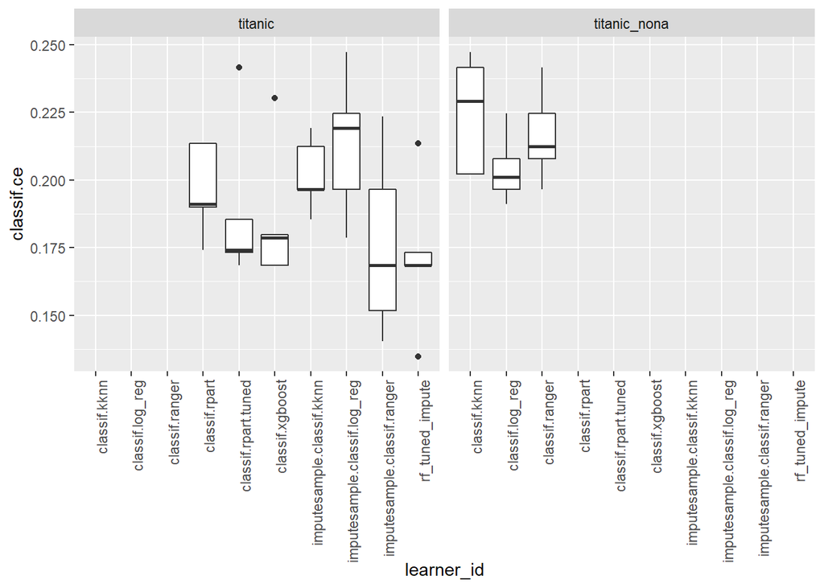

```r
# combine the new results with previuys results
res4 = as_benchmark_result(rsmpl_res_graph_at)
res$combine(res4)
mlr3viz::autoplot(res) + theme(axis.text.x = element_text(angle = 90, hjust = 1))
```